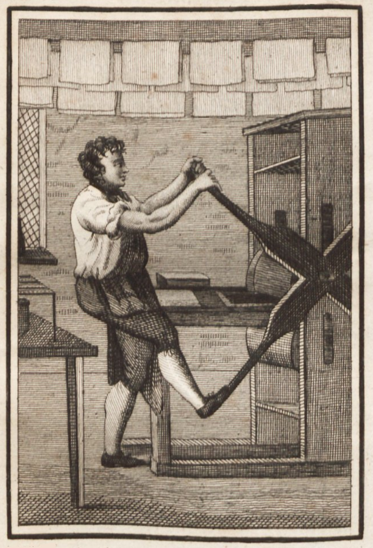

# Publications

Citations: 1679 | h-index: 22 | i10-index: 40

Source: Google Scholar

[Google Scholar](https://scholar.google.com/citations?hl=en&user=uOjMofAAAAAJ) [ORCID](https://orcid.org/0000-0002-9231-1337)

### Journal Articles

(peer-reviewed)

> 27. **Jannot, JE**, TP Good, VJ Tuttle. 2025. Seabird cable strike mortalities in the US West Coast At-sea Hake Fishery. *in prep. for Endangered Species Research*
> 26. Gredzens, C, A Kingham, **JE Jannot**. 2025. Evaluating and advancing the use of shore-based observers for scientific sampling and catch verification in high-volume fisheries. *Fisheries Management and Ecology* [link](https://onlinelibrary.wiley.com/doi/epdf/10.1111/fme.70039)
> 25. Good, T, **JE Jannot**, KA Somers, EJ Ward. 2022. Using Bayesian time series models to estimate bycatch of an endangered albatross. *Fisheries Research* [link](https://www.sciencedirect.com/science/article/abs/pii/S0165783622002697)
> 24. **Jannot, JE**, EJ Ward, KA Somers, BE Feist, TP Good, D Lawson, JV Carretta. 2021. Bayesian time-series analyses for estimating marine mammal bycatch: humpback whale entanglements in U.S. west coast fisheries. Special invited issue of *Frontiers in Marine Science: Assessment Approaches to Support Bycatch Management for Marine Mammals*, (eds., T Francis, J Moore, AE Punt, R Reeves). [link](https://www.frontiersin.org/articles/10.3389/fmars.2021.775187/full)
> 23. Pons, M, D Ovando, S Andraka, S Brodie, A Domingo, M Fitchett, R Forselledo, M Hall, EL Hazen, **JE Jannot**, *et al*. 2021. Tradeoffs between bycatch and target catches in static versus dynamic fishery closures. *Proceedings of the National Academy of Sciences* [link](https://doi.org/10.1073/pnas.2114508119)
> 22. **Jannot, JE**, R Bjorkland, KA Somers, T Mitchell, VJ Tuttle, J McVeigh. 2021. Elasmobranch bycatch in US West Coast Fisheries. *Endangered Species Research* [link](https://www.int-res.com/prepress/n01121.html)
> 21. Stock, BC, EJ Ward, T Eguchi, **JE Jannot**, JT Thorson, BE Feist, BX Semmens. 2020. Comparing predictions of fisheries bycatch using multiple spatiotemporal species distribution frameworks. *Canadian Journal of Fisheries and Aquatic Sciences* [link](https://cdnsciencepub.com/doi/abs/10.1139/cjfas-2018-0281)
> 20. Barnett, LAK, EJ Ward, **JE Jannot**, AO Shelton. 2019. Dynamic spatial heterogeneity reveals interdependence of marine faunal density and fishery removals. *Ecological Indicators* [link](https://doi.org/10.1016/j.ecolind.2019.105585)
> 19. Stock, BC, EJ Ward, JT Thorson, **JE Jannot**, BX Semmens. 2018. The utility of spatial model-based estimators of unobserved bycatch. *ICES Journal of Marine Science* [link](https://doi.org/10.1093/icesjms/fsy153)
> 18. Gladics, AJ, EF Melvin, RM Suryan, TP Good, **JE Jannot**, TJ Guy. 2017. Fishery-specific solutions to seabird bycatch in the U.S. West Coast sablefish fishery. *Fisheries Research* [link](https://www.sciencedirect.com/science/article/pii/S0165783617302291)
> 17. Thorson, JT, **JE Jannot**, K Somers. 2016. Using spatio-temporal models of population growth and movement to monitor overlap between human impacts and fish populations. *Journal of Applied Ecology* [link](https://besjournals.onlinelibrary.wiley.com/doi/full/10.1111/1365-2664.12664)
> 16. Bjorkland, R, DC Dunn, M McClure, **J Jannot**, MA Bellman, M Gleason, K Schiffers. 2015. Spatiotemporal patterns of rockfish bycatch in US west coast groundfish fisheries: opportunities for reducing incidental catch of depleted species. *Canadian Journal of Fisheries and Aquatic Sciences* [link](https://cdnsciencepub.com/doi/10.1139/f01-074)
> 15. Ward, E., **JE Jannot**, YW Lee, K Ono, AO Shelton, JT Thorson. 2015. Using spatio-temporal species distribution models to identify temporally evolving hotspots of species co-occurrence. *Ecological Applications* [link](https://esajournals.onlinelibrary.wiley.com/doi/10.1890/15-0051.1)
> 14. **Jannot, JE** and D Holland. 2013. Identifying ecological and fishing drivers of bycatch in a U.S. groundfish fishery. *Ecological Applications* [link](https://esajournals.onlinelibrary.wiley.com/doi/10.1890/12-2225.1)
> 13. Holland, D and **JE Jannot**. 2012. Bycatch risk pools for the US West Coast Groundfish Fishery. *Ecological Economics* [link](https://www.sciencedirect.com/science/article/abs/pii/S0921800912001401)
> 12. Herrmann, D, A Ko, S Bhatt, **JE Jannot**, and SA Juliano. 2010. Geographic variation in size and oviposition depths of lubber grasshoppers (Romalea microptera) is associated with different soil conditions. *Annals of the Entomological Society of America* 103:227-235
> 11. **Jannot, JE** 2009. Life history plasticity and post-metamorphic fitness consequences of proximate cues of pond-drying on an aquatic insect. *Oecologia* 161:267-277
> 10. **Jannot, JE**, A Ko, L Skinner, D Herrmann, E Butzen, O Akman, SA Juliano. 2009. Density-dependent polyphenism leads to geographic variation in size among two populations of lubber grasshoppers. *Ecological Entomology* 34:644-651
> 9. **Jannot, JE**, J Brinton, K Kocot, O Akman, SA Juliano. 2009. Ontogenetic mechanisms underlying a geographic size cline in a grasshopper (*Romalea microptera*). *Annals of the Entomological Society of America* 102: 467-475
> 8. **Jannot, JE**, O Akman, BL Kerans, K Carr. 2008. Using neural networks to detect patterns in inter-specific data: an example from net-spinning caddisflies. *Ecological Informatics* 3: 387-396
> 7. **Jannot, JE**, SA Wissinger, JR Lucas. 2008. Diet and pond-drying affect life history trade-offs in a caddisfly (Trichoptera: Limnephilidae). *Biological Journal of the Linnean Society* 95: 495-504
> 6. Kruezer, A, J Walrath, MHirsh, D Pitynski, O Akman, **J Jannot**, SA Juliano. 2008. Immune function, body size, and parasite load in lubber grasshoppers. *Am. J. Undergrad. Res.* 7 (3): 25-30
> 5. Akman, O, J Gamage, **J Jannot**, S Juliano, A Thurman, D Whitman. 2007. A simple test for length-biased sampling. *JP Journal of Biostatistics* 1:189-195
> 4. **Jannot, JE**, E Bruneau, SA Wissinger. 2007. Effects of larval energetic resources on life history and adult allocation patterns in a caddisfly (Trichoptera: Phryganeidae). *Ecological Entomology* 32: 376-383
> 3. Kerans, BL, MF Dybdahl, MM Gangloff, **JE Jannot**. 2005. Potomopyrgus antipodarum: distribution, density, and effects on native macroinvertebrate assemblages in the Greater Yellowstone Ecosystem. *Journal of the North American Benthological Society* 24:123-138
> 2. **Jannot, JE** and BL Kerans. 2003. Body size, sexual size dimorphism, and Rensch’s rule in adult hydropsychid caddisflies (Trichoptera: Hydropsychidae). *Canadian Journal of Zoology* 81: 1956-1964
> 1. Wissinger, SA, WS Brown, **JE Jannot**. 2003. Caddisfly life histories and distributions along permanence gradients in high-elevation wetlands. *Freshwater Biology* 48: 255-270

### Technical Reports

For a complete list of all technical publications, see [NOAA’s Institutional Repository](https://repository.library.noaa.gov/) (search for “Jannot”)

- Alaska Fisheries Science Center and Alaska Regional Office. 2025. North Pacific Observer Program 2024 Annual Report. AFSC Processed Rep. 2025-10, 139 p. Alaska Fish. Sci. Cent., NOAA, Natl. Mar. Fish. Serv., 7600 Sand Point Way NE, Seattle WA 98115. [link](https://repository.library.noaa.gov/view/noaa/71182)
- Brower, A. et al. 2025. Human-caused Mortality and Injury of NMFS-managed Alaska Marine Mammal Stocks, 2019-2023. AFSC Processed Rep. 2025-13, 9 p. + Supporting files. Alaska Fish. Sci. Cent., NOAA, Natl. Mar. Fish. Serv., 7600 Sand Point Way NE, Seattle WA 98115. [link](https://repository.library.noaa.gov/view/noaa/71570)
- Van Horn, C, A Kingham, **JE Jannot**. 2025. A summary of post-cruise data loss in the North Pacific Observer Program 2014-2023. NOAA Technical Memorandum NMFS-AFSC-500. [link](https://repository.library.noaa.gov/view/noaa/71155)
- Gustafson R, KE Richerson, KA Somers, VJ Tuttle, **JE Jannot**. 2022. Information in Support of a Five-Year Status Review of Eulachon (*Thaleichthys pacificus*) Listed under the Endangered Species Act: Southern Distinct Population Segment. U.S. Department of Commerce, NOAA Technical Memorandum NMFS-NWFSC-179. [link](https://doi.org/10.25923/p7mr-sk77)
- **Jannot, JE**, KA Somers, VJ Tuttle, J Eibner, KE Richerson, JT McVeigh, JV Carretta, NC Young, J Freed. 2022. Marine Mammal Bycatch in U.S. West Coast Groundfish Fisheries, 2002-19. U.S. Department of Commerce, NOAA Technical Memorandum NMFS NWFSC-176. [link](https://doi.org/10.25923/h6gg-c316)
- Richerson KE, **JE Jannot**, JT McVeigh, KA Somers, VJ Tuttle, S Wang. 2022. Observed and Esti-mated Bycatch of Green Sturgeon in 2002-19 U.S. West Coast Groundfish Fisheries. NOAA Tech-nical Memorandum NMFS NWFSC-178. [link](https://doi.org/10.25923/tkp7-mj29)
- **Jannot, JE**, KE Richerson, KA Somers, VJ Tuttle, RS Shama, JT McVeigh. 2022. Pacific Halibut Bycatch in U.S. West Coast Groundfish Fisheries, 2002-20. U.S. Department of Commerce, NOAA Technical Memorandum NMFS-NWFSC-173. [link](https://repository.library.noaa.gov/view/noaa/34438)
- Gilman, E. et al. 2021. ACAP Guidelines on Fisheries Electronic Monitoring Systems. 10th Meeting of the Seabird Bycatch Working Group, ACAP, Hobart, AU. 17-19 August 2021.
- Somers, K A, **JE Jannot**, KE Richerson, VJ Tuttle, NB Riley, JT McVeigh. 2022. Estimated Discard and Catch of Groundfish Species in the 2020 U.S. West Coast Fisheries. U.S. Department of Commerce, NOAA Technical Memorandum NMFS-NWFSC-175. [link](https://repository.library.noaa.gov/view/noaa/35780)
- **Jannot, JE**, A Wuest, TP Good, KA Somers, VJ Tuttle, KE Richerson, RS Shama, JT McVeigh. 2021. Seabird Bycatch in U.S. West Coast Fisheries, 2002-18. U.S. Department of Commerce, NOAA Technical Memorandum NMFS-NWFSC-165. [link](https://repository.library.noaa.gov/view/noaa/28765)